# Interpretations et explications de la regression multinomiale

Chiara Coppa

12/3/2022

# Introduction

La première étape de ce travail est la réalisation d’une régression logistique multinomiale, un modèle statistique qui permet d’analyser la relation entre un ensemble de données quantitatives et une variable dépendante qualitative, caractérisée par plus de deux catégories.

Dans l’étude de mes communes, à savoir les communes de Muri dans le canton d’Argovie et les communes d’Affoltern dans le canton de Zurich, j’ai choisi comme variable catégorielle la typologie des communes divisée en trois catégories, proposée par l’Office fédérale de la statistique. La première attribue à la commune la classification “Urbain”, la deuxième attribue la catégorie “Intermédiaire”, qui se réfère aux communes périurbaines denses et aux centres ruraux, et la troisième attribue la classification “Rural” (OFS, 2017).

Pour l’ensemble des variables quantitatives indépendantes, j’ai sélectionné cinq différents indicateurs:

- La proportion de personnes actives occupées dans le secteur économique *primaire*
- La proportion de personnes actives occupées dans le secteur économique *secondaire*

J’ai calculé les deux indicateurs en divisant le nombre de personnes actives dans le secteur pour le nombre de personnes actives totales dans les trois secteurs économiques.

- La proportion de surface agricole, calculée en divisant la valeur de la surface agricole par la valeur de la surface totale de la commune
- La proportion de la surface d’habitat et d’infrastructure, calculée en divisant la valeur de la surface d’habitat et d’infrastructure par la valeur de la surface totale de la commune
- La proportion de Oui dans la votation de l’Initiative populaire du 25 novembre 2018 intitulée «Pour la dignité des animaux de rente agricoles (initiative pour les vaches à cornes)».

J’ai calculé tous ces indicateurs pour les communes précédemment citées. Les indicateurs datent tous du 2018, sauf pour la typologie des communes qui date du 2012. À cause de l’absence de données pour certaines communes dans les secteurs économiques, pour faire fonctionner la régression logistique multinomiale, j’ai été obligée d’éliminer deux communes: Hedingen (dans le district d’Affoltern) et Aristau (dans le district de Muri).

Grâce à l’étude territoriale dans le cadre du Travail Pratique 1, j’ai pris connaissance que mes communes sont en majorité rurales. À partir de ça, j’ai choisi des indicateurs qui peuvent être plus significatifs pour ces communes comme les proportions de personnes actives dans les secteurs primaire et secondaire et la proportion de surface agricole, que j’imagine sont plus prédominantes dans ces communes. Ensuite, j’ai choisi la proportion d’habitat et infrastructure, que j’imagine moins prédominant par rapport aux communes plus urbaines, et la proportion de l’Initiative populaire qui a touché principalement le secteur agricole (plus important dans ces communes).

Avec tous ces indicateurs, j’ai créé un tableau .tsv que j’ai chargé (à travers la commande read.delim) dans R pour commencer la réalisation de mon modèle.

# Évaluation du modèle

Pour réaliser le modèle de régression logistique multinomiale, j’ai tout d’abord téléchargé le package “nnet” qui contient la fonction “multinom” que je vais utiliser pour créer le modèle.

Pour tester la précision de mon modèle en fonction des indicateurs choisis, j’ai divisé mes données en deux jeux de données: - un de *calibration* avec le 90% des valeurs initiales, pour définir les paramètres du modèle - un de *test* avec le 10% des valeurs initiales, pour évaluer la qualité du modèle

Ensuite, j’ai effectué ma régression multinomiale sur les données de calibration pour définir les paramètres du modèle (à travers le code “multinom”). Après, j’ai appliqué mon modèle aux données de calibrage et de test à travers la commande “predict” pour prédire sur ces données la catégorie de la typologie des communes et je les ai visualisées dans deux tableaux (avec “table”). Les valeurs sur la diagonale sont les nombres de cas dans lequel le modèle a prédit correctement, tandis que dans les autres positions, on trouve les nombres de cas de mauvaise prédiction. À partir de ces résultats, j’ai calculé la proportion de régions classées correctement pour les deux jeux de données. “Summary” m’a permis d’afficher les coefficients, la déviance et l’AIC. La déviance et l’AIC doivent être des valeurs petites pour avoir un modèle satisfaisant, mais elles ne sont pas des conditions suffisantes à le valider.

Par conséquent, pour valider mon modèle, j’ai effectué une boucle de 1000 itérations:

J’ai répété les étapes d’avant et je les ai mis dans une boucle “for” pour répéter les calcules 1000 fois afin d’obtenir 1000 valeurs de la proportion de précision du modèle à prédire la typologie des communes. J’ai calculé ensuite la moyenne de la précision et la variance (la dispersion) des 1000 valeurs. Ces calculs me donnent une valeur pour la moyenne d’environ 0,85 et 0.70 pour les données de calibrage et respectivement de test et d’environ 0,001 et 0,04 pour la variance. La prédiction est donc satisfaisante parce que la moyenne de la précision est assez élevée et la dispersion des valeurs par rapport à la moyenne est très faible. Grâce à cette boucle, les valeurs de la déviance et de l’AIC se sont réduites en rendant le modèle plus satisfaisant.

# La prédiction à travers le modèle validé

Une fois validé le modèle, j’ai pu l’appliquer à toutes mes communes de base initiales. À travers la fonction “multinom”, j’ai effectué ma régression logistique multinomiale sur toutes mes données initiales (sans diviser en test et train). Ensuite à travers la fonction “predict” j’ai fait prédire au modèle la typologie de toutes les communes de ma région et avec “table” je les ai visualisées sous forme de tableau. J’ai vu, à travers le tableau, que les communes classées correctement sont 27, tandis que les communes qui n’ont pas été classées correctement sont 4. À travers la commande “write.table” j’ai créé et exporté un tableau indiquant les catégories de la typologie des communes prédites par le modèle. Ensuite, j’ai ouvert le tableau avec Excel et j’ai copié-collé la classification fournie par l’OFS et les noms des communes.

À partir de ce nouveau tableau, en comparant les deux colonnes de la typologie des communes (prédiction et OFS), j’ai pu constater quelles communes ont été classées de manière incorrecte par le modèle. Les 4 communes sont Hausen am Albis dans le district d’Affoltern et Boswil, Bünzen et Sins dans le district de Muri. Les erreurs pour ces 4 communes sont de deux typologies sur les six possibles: la commune de Boswil a été classée comme commune rurale au lieu d’intermédiaire, tandis que les trois autres ont été classées comme intermédiaires au lieu de rurales. La carte suivante montre les communes des deux districts. Avec deux couleurs différentes, j’ai mis en évidence les quatre communes qui n’ont pas été classées correctement par le modèle en fonction des deux erreurs différents indiqués avant. Les deux communes que j’ai dû enlever pour un manque de données, je les ai colorées avec une tonalité de gris pour les différencier.

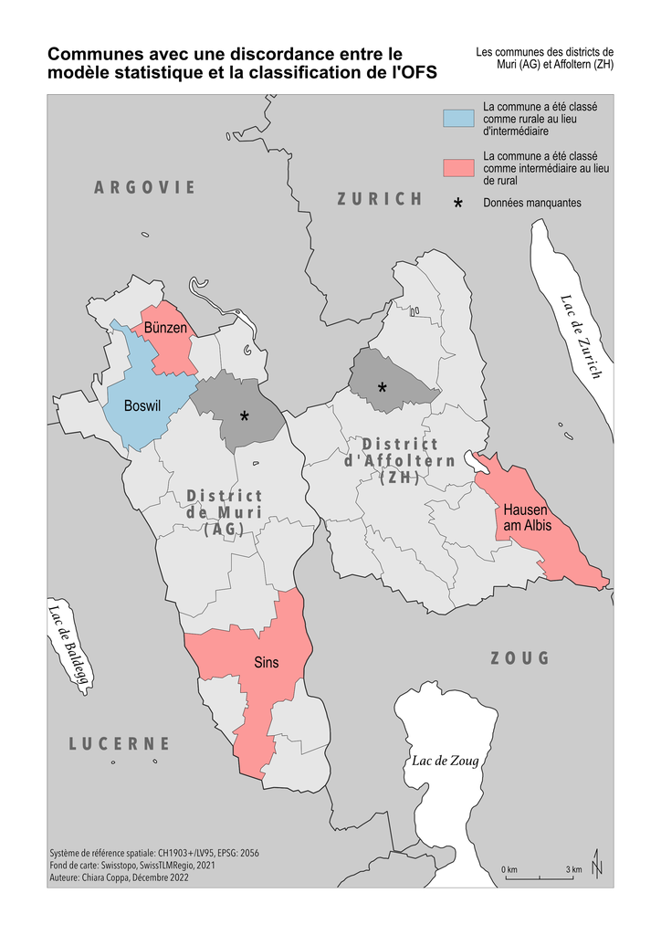

# Sources

OFS (2017, mai 9). Niveaux géographiques de la Suisse—Typologie des communes et typologie urbain-rural 2012. Office fédéral de la statistique. https://www.bfs.admin.ch/asset/fr/2543324